# Descriptive Statistics: Participants

Erin Buchanan

2024-06-20

Please note that this file only includes languages that are analyzed in the full paper. You can view complete data demographics by using this markdown file and turning off the data filter.

The links to the language files can be found in our supplemental materials. The paper is presented with an upcoming *R* package `semanticprimeR` that allows one to open data files directly in *R* and a Shiny application to download a specific set of language files (Chang et al. 2023; The Doom Lab and Buchanan 2024). The data can be cited using our Zenodo doi (Buchanan et al. 2024) which will indicate which version of the data was examined.

# Participant level data

## Gender

Participants were generally female (55.49%) or male (37.39)% with the rest either missing data, not wanting to indicate their gender or other. If data was filtered to only participants that were kept for analysis, the data was again predominantly female (60.95%) or male (37.44)%.

### Overall Gender

| Gender | Percent |
| --- | --- |
| Missing | 5.80 |
| Female | 55.49 |
| Male | 37.39 |
| Not Say | 0.58 |
| Other | 0.75 |

### Gender for Original Accuracy Participants

| Gender | Percent |
| --- | --- |
| Missing | 0.37 |
| Female | 60.95 |
| Male | 37.44 |
| Not Say | 0.47 |
| Other | 0.76 |

### Gender for Rescored Accuracy Participants

| Gender | Percent |
| --- | --- |
| Missing | 0.38 |
| Female | 60.54 |
| Male | 37.86 |
| Not Say | 0.47 |
| Other | 0.74 |

## Education Levels

Participants indicated they had completed high school (42.77%), some college (7.63%), college (30.47%), master’s (9.30%), and the rest other options (Less than High School, Missing, or Doctorate). Participants kept for analysis also followed this pattern: high school (46.02%), some college (8.34%), college (31.97%), master’s (9.61%).

### Overall Education

| Education | Percent |
| --- | --- |
| Missing | 5.59 |
| Less than High School | 2.34 |
| High School | 42.77 |
| Some College | 7.63 |
| College | 30.47 |
| Masters | 9.30 |
| Doctorate | 1.90 |

### Education for Original Accuracy Participants

| Education | Percent |
| --- | --- |
| Missing | 0.19 |
| Less than High School | 2.25 |
| High School | 46.02 |
| Some College | 8.34 |
| College | 31.97 |
| Masters | 9.61 |
| Doctorate | 1.61 |

### Education for Rescored Accuracy Participants

| Education | Percent |
| --- | --- |
| Missing | 0.21 |
| Less than High School | 2.23 |
| High School | 45.80 |
| Some College | 8.27 |
| College | 32.09 |
| Masters | 9.73 |
| Doctorate | 1.67 |

## Native Language

| Native Language | Overall Percent | Keep Percent |
| --- | --- | --- |
| English | 15.83 | 17.19 |
| Turkish | 8.41 | 8.63 |
| German | 7.80 | 9.39 |
| Missing | 7.76 | 1.65 |
| Russian | 7.61 | 6.99 |
| Spanish | 5.39 | 6.13 |
| Japanese | 5.03 | 4.51 |
| Polish | 4.36 | 4.65 |
| Korean | 4.23 | 3.81 |
| Portuguese | 4.06 | 4.37 |
| Czech | 3.88 | 4.07 |
| Italian | 3.74 | 4.38 |
| French | 2.80 | 3.31 |
| Danish | 2.79 | 3.20 |
| Hungarian | 2.72 | 2.96 |
| Mandarin | 2.58 | 2.68 |
| Greek | 2.35 | 2.73 |
| Serbian | 2.27 | 2.66 |
| Romanian | 1.99 | 2.23 |
| Chinese | 0.62 | 0.57 |

### Overall Native Language

Please see https://osf.io/ta6wf for a summarized list of all native languages.

### Native Language for Original Accuracy Participants

Please see https://osf.io/652h8 for a summarized list of all native languages for participants used in analysis.

### Native Language for Rescored Accuracy Participants

Please see https://osf.io/b3y6r for a summarized list of all native languages for rescored accuracy in native language.

## Average Age

The average age for all participants was $M$ = 31.38 ($SD$ = 14.95) ranging from 18.00 to 104.00. The demographic question asked participants to enter their year of birth, and the high maximum values were likely participants who entered the minimum possible year allowable in the data collection form. The participants kept for analysis showed the same pattern of ages: $M$ = 30.43 ($SD$ = 14.17) ranging from 18.00 to 104.00.

The median age was 24.00 with an IQR of 20.00 to 39.00. The median age for analyzed participants was 24.00 with an IQR of 20.00 to 37.00.

The rescored accuracy participants showed the following age pattern: $M$ = 30.76 ($SD$ = 14.37) ranging from 18.00 to 104.00. The median age for rescored participants was 24.00 with an IQR of 20.00 to 38.00.

## Operating System

The majority of participants used a Windows based operating system (76.91%) followed by Mac OS (18.45%), and Linux (1.80%), with some missing data (2.85%). The operating systems were the same for the participants used in analysis: Windows (76.82%), Mac (18.70%), Linux (1.86%), and Missing (2.61%).

### Overall Operating System

| Operating System | Percent |
| --- | --- |
| Linux | 1.80 |
| Mac | 18.45 |
| Missing | 2.85 |
| Windows | 76.91 |

### Operating System for Original Accuracy Participants

| Operating System | Percent |
| --- | --- |
| Linux | 1.86 |
| Mac | 18.70 |
| Missing | 2.61 |
| Windows | 76.82 |

### Operating System for Rescored Accuracy Participants

| Operating System | Percent |
| --- | --- |
| Linux | 1.85 |
| Mac | 18.44 |
| Missing | 2.58 |
| Windows | 77.13 |

## Web Browser

Web browsers were grouped into the largest categories for reporting. The large majority of participants used Chrome (58.96%), followed by Edge (14.92%), Firefox (8.18%), Safari (8.88%), and Opera (3.09%) A surprise result was that the Russian browser Yandex contributed a small (but not extremely small) percent of the browser usage: (2.37%), followed by other web browsers (3.60%) The results were the same when examining participants who were kept for analysis: Chrome (59.81%), Edge (14.23%), Firefox (8.43%), Safari (9.22%), Opera (2.99%), Yandex (2.03%), and Other (3.29%).

### Overall Web Browser

| Web Browser | Percent |
| --- | --- |
| Chrome | 58.96 |
| Edge | 14.92 |
| Firefox | 8.18 |
| Opera | 3.09 |
| Other | 3.60 |
| Safari | 8.88 |
| Yandex | 2.37 |

### Web Browser for Original Accuracy Participants

| Web Browser | Percent |
| --- | --- |
| Chrome | 59.81 |
| Edge | 14.23 |
| Firefox | 8.43 |
| Opera | 2.99 |
| Other | 3.29 |
| Safari | 9.22 |
| Yandex | 2.03 |

### Web Browser for Rescored Accuracy Participants

| Web Browser | Percent |
| --- | --- |
| Chrome | 59.60 |
| Edge | 14.41 |
| Firefox | 8.39 |
| Opera | 3.05 |
| Other | 3.29 |
| Safari | 9.07 |
| Yandex | 2.18 |

## Language Locale

| Browser Language | Overall Percent | Keep Percent |
| --- | --- | --- |
| English | 27.35 | 27.65 |
| Turkish | 8.60 | 8.30 |
| German | 8.53 | 9.72 |
| Russian | 8.10 | 6.99 |
| Japanese | 5.54 | 4.57 |
| Spanish | 4.85 | 5.35 |
| Korean | 4.58 | 3.72 |
| Polish | 4.35 | 4.35 |
| Czech | 4.15 | 4.04 |
| Portuguese | 3.98 | 4.15 |
| Italian | 3.54 | 4.09 |
| Missing | 2.85 | 2.61 |
| French | 2.83 | 3.25 |
| Danish | 2.61 | 2.90 |
| Chinese | 2.43 | 2.24 |
| Hungarian | 2.36 | 2.45 |
| Greek | 1.60 | 1.73 |
| Romanian | 0.96 | 1.08 |
| Serbian | 0.45 | 0.50 |
| Dutch | 0.14 | 0.16 |

### Overall Browser Language

Please see https://osf.io/93kep for a summarized list of all browser languages.

### Browser Language for Original Accuracy Participants

Please see https://osf.io/3yab7 for a summarized list of all browser languages for participants used in analysis.

Please see https://osf.io/adhbe for a summarized list of all browser languages for rescored accuracy in native language.

## Data by Lab

Please see summary report located at: https://osf.io/ty4hp which includes gender, education, age, and sample size counts for a summary. This table also includes information about the ethics submissions and data collection procedures for each lab.

- Native Language by Lab: https://osf.io/hnrgk
- Operating System by Lab: https://osf.io/gud6v
- Web Browser by Lab: https://osf.io/egk9w
- Language Locale by Lab: https://osf.io/wt3xn

## Data by Language

Please see summary report located at: https://osf.io/y3dk7. This summary includes gender, education, and age information by language.

- Native Language by Language: https://osf.io/5b72x
- Operating System by Language: https://osf.io/9dwqb
- Web Browser by Language: https://osf.io/bn7uv
- Language Locale by Language: https://osf.io/dyh4e

## Map of Participant Recruitment

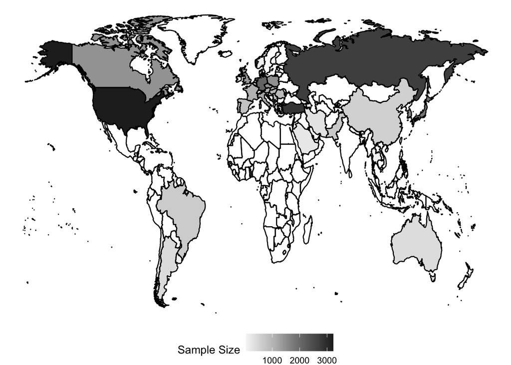

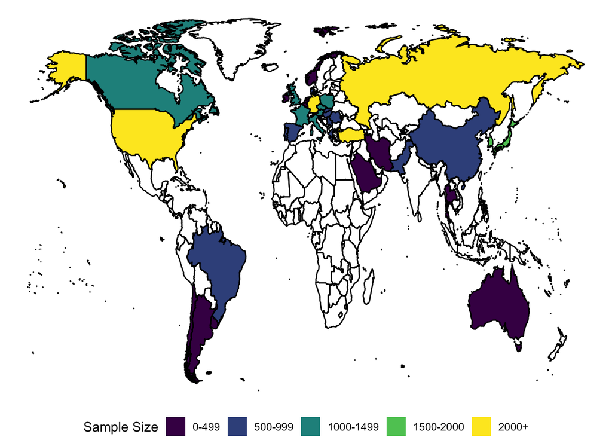

Buchanan, Erin, Kelly Cuccolo, Tom Heyman, Aishwarya Iyer, Nicholas Coles, Neil Lewis Jr, Kim Peters, et al. 2024. “SemanticPriming/SPAML: SPAML V1 Data Release.” Zenodo. https://doi.org/10.5281/ZENODO.10888833.

Chang, Winston, Joe Cheng, JJ Allaire, Carson Sievert, Barret Schloerke, Yihui Xie, Jeff Allen, Jonathan McPherson, Alan Dipert, and Barbara Borges. 2023. “Shiny: Web Application Framework for r.” https://CRAN.R-project.org/package=shiny.